# CS CM121 Final Project

Ellen Wei

March 17, 2022

## K-means clustering

```r
source("project_function.R")
```

```
## VIM is ready to use.
```

```
## Suggestions and bug-reports can be submitted at: https://github.com/statistikat/VIM/issues
```

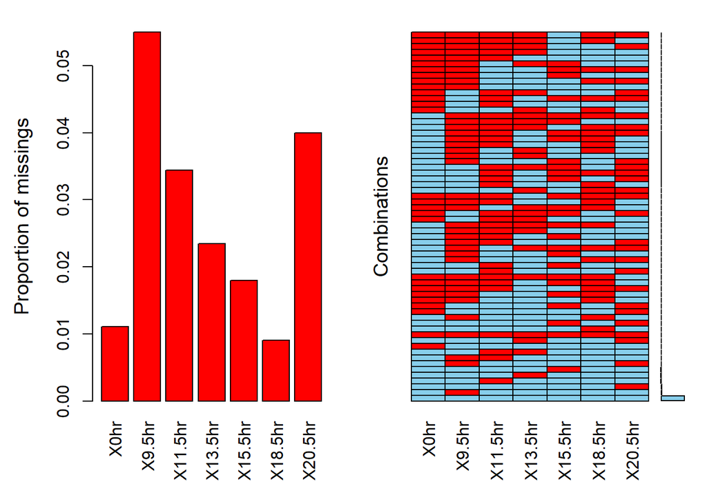

```
## Number of NA's in  X0hr = 71
## Number of NA's in  X9.5hr = 352
## Number of NA's in  X11.5hr = 220
## Number of NA's in  X13.5hr = 150
## Number of NA's in  X15.5hr = 115
## Number of NA's in  X18.5hr = 58
## Number of NA's in  X20.5hr = 256
```

```r
library(tidyverse)
library(dplyr)
```

Cluster the data using various values for k and inspect the following: (1) how different the cluster means look, (2) how the outliers look in the different clusters

```r
k_means(data, k=2)
```

```
## Iterations:  24
```

```
##          X0hr      X9.5hr     X11.5hr    X13.5hr    X15.5hr    X18.5hr
## 1 -0.11262280 -0.06523613  0.14963904  0.1648802  0.1834103  0.9426264
## 2  0.03335309  0.05328242 -0.05564685 -0.1323035 -0.1913817 -0.3663951
##      X20.5hr cluster
## 1  0.8554267       1
## 2 -0.3433324       2
```

```r
k_means(data, k=4)
```

```
## Iterations:  36
```

```
##          X0hr      X9.5hr     X11.5hr       X13.5hr     X15.5hr    X18.5hr
## 1 -0.06968871 -0.02602243  0.02725316 -0.0071734920 -0.05323494  0.3075413
## 2  2.56088889 -0.36278704 -0.07030291 -0.0001473778  0.04039136  0.2793415
## 3 -0.10497912 -0.02028513  0.23592830  0.3803533155  0.49419060  1.5486506
## 4  0.09620242  0.08286854 -0.06763645 -0.2219185151 -0.27920759 -0.8574460
##       X20.5hr cluster
## 1  0.26060265       1
## 2  0.03789974       2
## 3  1.54965395       3
## 4 -0.84711157       4
```

```r
k_means(data, k=7)
```

```
## Iterations:  21
```

```
##           X0hr      X9.5hr     X11.5hr     X13.5hr     X15.5hr    X18.5hr
## 1 -0.888556428  4.93097438 -4.63882526 -2.71447672  3.57664248  1.7197512
## 2 -0.127905663 -0.09546805  0.13369320  0.09571026  0.07757575  0.7644258
## 3 -0.032085164 -1.49492361  5.16000000  0.00091840  0.48831527  0.2204147
## 4 -4.491085345  4.15911118 -1.40303978  4.30508328 -6.30181297 -3.1176104
## 5 -0.094461264  0.03557859  0.24173416  0.51971446  0.69250674  1.9762311
## 6  0.144238352  0.10011149 -0.05930518 -0.29446238 -0.37892107 -1.2268836
## 7  0.007241726  0.04510661 -0.05346449 -0.08043914 -0.12615740 -0.1124159
##       X20.5hr cluster
## 1 -4.96206170       1
## 2  0.62055623       2
## 3  1.40800000       3
## 4  5.39254180       4
## 5  2.08940977       5
## 6 -1.24647661       6
## 7 -0.06977956       7
```

For k = 2, the cluster means look quite different. The values are quite far from each other. For k = 4, the cluster means still show vast differences. The means span the entire range, and none of them are particularly close to each other. For k = 7, the cluster means show some similarities but still with a large range of values. Considering that each column is a point in time, we could plot these as a time graph and follow the trajectories. In this sense, the trajectories are still very varied and different from each other.

The data has missing values. One method would have been to remove all the rows including NA values, but I chose to replace the NA’s with the column mean so that I could still keep those observations.

A different clustering method is hierarchical clustering, implemented below.

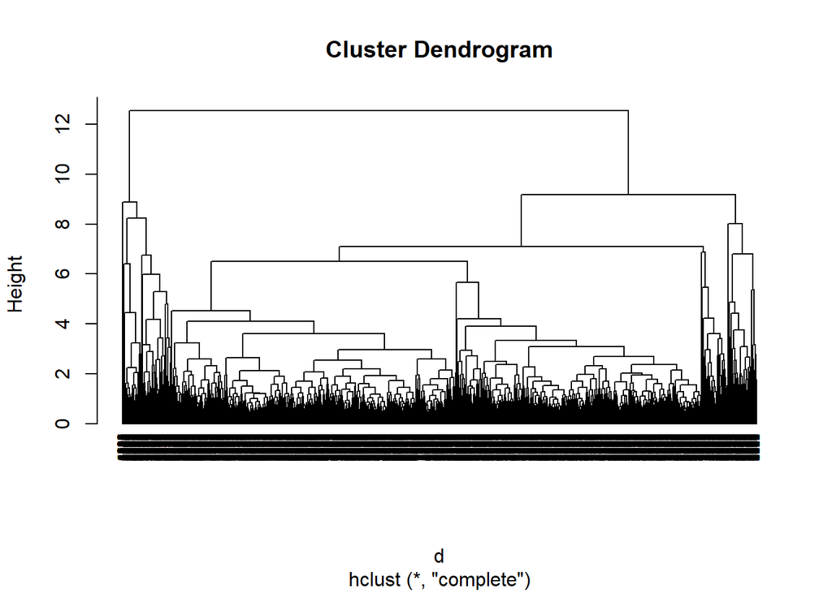

```r
# Dissimilarity matrix
d <- dist(data, method = "euclidean")

# Hierarchical clustering using Complete Linkage
hc1 <- hclust(d, method = "complete" )

# Plot the obtained dendrogram
plot(hc1, cex = 0.6, hang = -1)
```

Comparing the results: Hierarchical clustering can roughly show the relative distances between centres when using different values of k. It is useful for deciding how many k-centroid values to use. The k-means clustering method is useful when the k is known or given and can group observations together intuitively. These can be used in conjuction: first apply hierarchical clustering to decide how many k’s should be used, then k-means clustering with that k value. Hierarchical is definitely faster in this implementation. However, one is not better than the other since we have slightly different usages for them.